# Medidas de tendencia central y dispersión

Anderson N. Soriano-Moreno

2020/08/05

## 0.1 Importando base de datos

### 0.1.1 En CSV

1. Utilizamos el comando **"read.csv()**"
2. Entre dos paréntesis y dos comillas ponemos la dirección de base de datos en formato *csv*.
3. Cargamos la base de datos con el nombres “datos” que lo ponemos a la izquierda después de una flecha **“<-”**.

Mira el ejemplo.

```r
datos <- read.csv("~Documentos/Proyecto/base_datos.csv")
```

### 0.1.2 En Excel

1. Instalamos el paquete **“readxl”** con el comando **install.packages(“readxl”)**
2. Cargamos el paquetes **“readxl”** con el comando **library(readxl)**
3. Utilizamos el comando **“read_xlsx()”**. Entre dos paréntesis y dos comillas ponemos la dirección de base de datos en formato *xlsx*.
4. Cargamos la base de datos con el nombres “datos” que lo ponemos a la izquierda después de una flecha **“<-”**.

Mira el ejemplo.

```r
install.packages("readxl")
library(readxl)
datos <- read_xlsx("~Documentos/Proyecto/base_datos.xlsx")
```

## 0.2 Explorando base

### 0.2.1 Visualizandola

Usamos el comando **head()**

```r
head(datos)
```

```
##      genero edad  pab pct_grasa  imc
## 1  Femenino   18 81.5      24.9 22.7
## 2 Masculino   17 81.0      11.6 20.8
## 3  Femenino   17 87.5      43.8 28.0
## 4  Femenino   20 75.0      26.9 23.7
## 5 Masculino   20 69.0      11.0 18.3
## 6  Femenino   17 69.5      28.0 20.4
```

### 0.2.2 Viendo clases de variables

Usamos el comando **str()**

```r
str(datos)
```

```
## 'data.frame':    280 obs. of  5 variables:
##  $ genero   : Factor w/ 2 levels "Femenino","Masculino": 1 2 1 1 2 1 1 2 2 1 ...
##  $ edad     : int  18 17 17 20 20 17 23 20 19 20 ...
##  $ pab      : num  81.5 81 87.5 75 69 69.5 93 70 70 67 ...
##  $ pct_grasa: num  24.9 11.6 43.8 26.9 11 28 35.6 15.7 7.5 21.4 ...
##  $ imc      : num  22.7 20.8 28 23.7 18.3 20.4 29.7 18.5 17.9 17.5 ...
```

## 0.3 Explorando variable

1. Para seleccionar una variable en R primero escribimos el nombre de la base de datos, en este caso *“datos”*. A continuación escribimos el símbolo **“$”**.
2. Si en este punto hacemos click en la tacla **Tab** en el taclado, aparecera un menu desplegable con el nombre de las variables que hay dentro de esa base de datos. Podemos seleccionar la variable que deseamos en ese menú, o también escribirla.

Para explorar la variable de forma general podemos utilizar el comando **“summary()”** que nos brindará varios parámetros descriptivos.

```r
summary(datos$edad)
```

```
##    Min. 1st Qu.  Median    Mean 3rd Qu.    Max.
##   15.00   18.00   20.00   20.18   21.00   31.00
```

De la misma forma, se puede calcular la **media, mediana, desviacion estandar y rangos intercuartílico**.

### 0.3.1 Media

```r
mean(datos$edad)
```

```
## [1] 20.18214
```

### 0.3.2 Mediana

```r
median(datos$edad)
```

```
## [1] 20
```

### 0.3.3 Desviación standar

```r
sd(datos$edad)
```

```
## [1] 2.80534
```

### 0.3.4 Rangos intercuartílicos

```r
quantile(datos$edad)
```

```
##   0%  25%  50%  75% 100%
##   15   18   20   21   31
```

## 0.4 Evaluando normalidad

### 0.4.1 Metodos descriptivos

Ahora si queremos calcular además la kurtosis y la skewness utilizaremos el comando “describe()” de la librería **“psych”**. Para esto, instalamos el paquete y seguido lo abrimos. Finalmente dentro del comando **“describe()”** ponemos la variable que deseemos evaluar.

```r
install.packages("psych")
library(psych)
```

Mira el ejemplo

```r
describe(datos$edad)
```

```
##    vars   n  mean   sd median trimmed  mad min max range skew kurtosis   se
## X1    1 280 20.18 2.81     20   19.85 2.97  15  31    16 1.24     2.03 0.17
```

```r
describe(datos$pab)
```

```
##    vars   n  mean   sd median trimmed mad  min   max range skew kurtosis   se
## X1    1 280 77.92 8.67     77   77.37 8.9 60.5 107.5    47 0.61     0.15 0.52
```

```r
describe(datos$pct_grasa)
```

```
##    vars   n  mean  sd median trimmed  mad min  max range  skew kurtosis   se
## X1    1 280 22.54 7.1  23.35   22.79 6.52   5 43.8  38.8 -0.24    -0.15 0.42
```

```r
describe(datos$imc)
```

```
##    vars   n  mean   sd median trimmed  mad  min  max range skew kurtosis   se
## X1    1 280 22.87 3.25   22.6   22.69 3.26 14.9 35.2  20.3 0.58     0.36 0.19
```

## 0.5 Metodos graficos

### 0.5.1 Histograma

Hay dos formas de realizar un histograma, utilizando el comando **hist()** o el comando **ggplot()**. Utilizamos la variable edad, de ejemplo.

```r
# Utilizando hist
hist(datos$variable)


# Utilizando ggplot
install.packages("tidyverse")
library(tidyverse)
ggplot(datos, aes(variable)) + geom_histogram()
```

#### 0.5.1.1 Ejemplo histograma

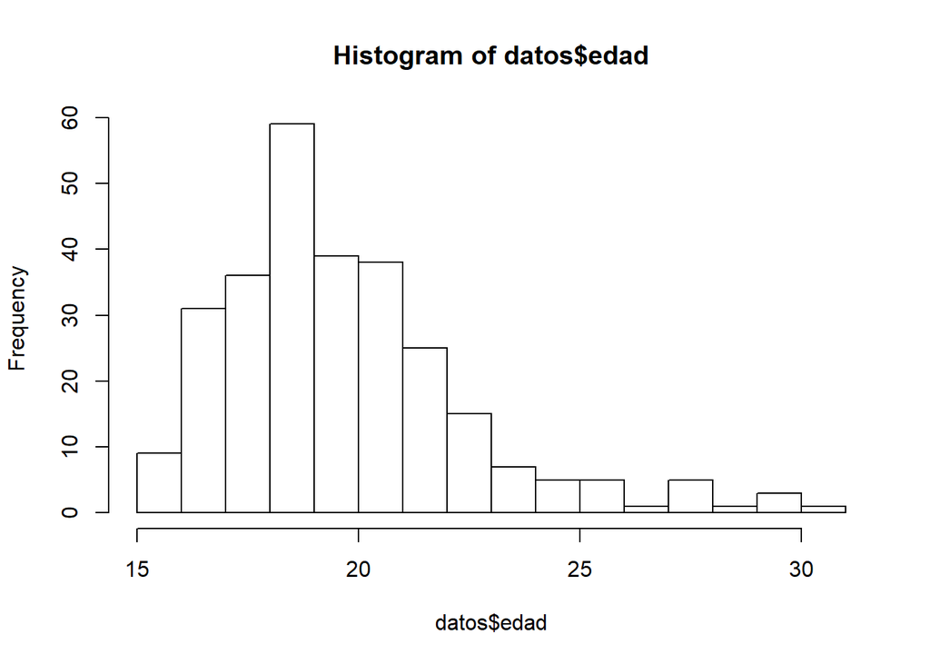

```r
hist(datos$edad, breaks = 20)
```

#### 0.5.1.2 Ejemplo ggplot

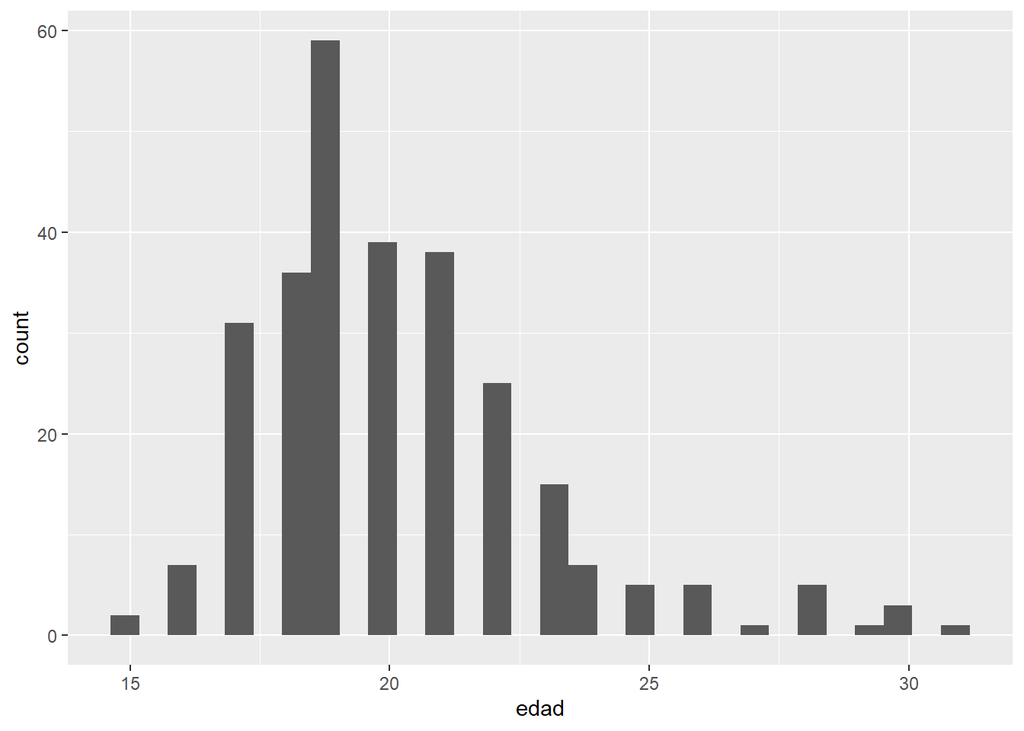

```r
ggplot(datos, aes(edad)) + geom_histogram()
```

#### 0.5.1.3 Gráfico quantil quantil

Utilizamos el paquete **ggpubr** y el comando **ggqqplot()**

```r
install.packages("ggpubr")
library(ggpubr)
ggqqplot(datos$variable)
```

#### 0.5.1.4 Ejemplo qqplot

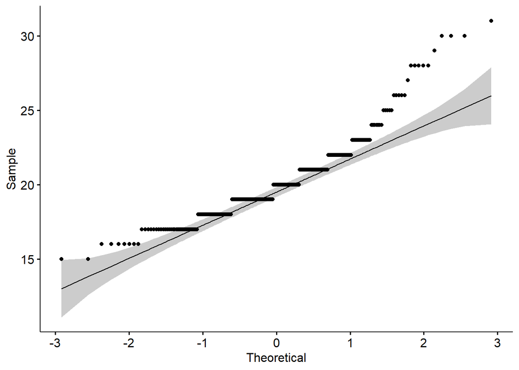

```r
ggqqplot(datos$edad)
```

### 0.5.2 Comparación hist y qqplot

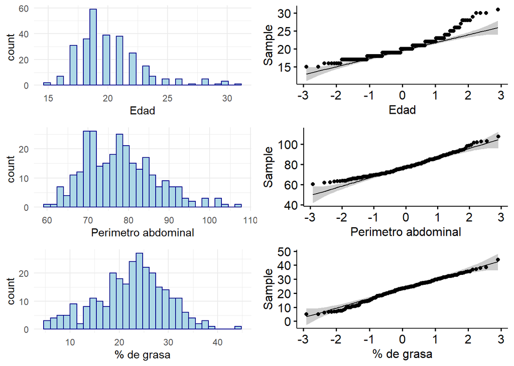